# final-ReadmissionRates

## Midterm - Mental Health Systems

### Manasvi Malepati

The Problem:

The problem I am exploring is related to the mental illness recovery system in the U.S. and its successfulness in its purpose. When those who are struggling with mental illnesses need serious and urgent care, they are typically hospitalized in and after being dicharged, the same people can sometimes get readmitted for the same reasons as before. One way that mental health programs on a state-wide or national level measure their efficacy is by looking at those readmission rates and seeing whether their program had brought those rates down. This is because if the patient had not been readmitted for the effects of their mental illness then the treatment they were seeking, a treatment that may have been provided by the program, may have been helping them recover.

Why Does This Matter?

Mental illness is a tough issue to tackle with the most serious of consequences. According to the National Alliance of Mental Illness, around 12.5% of visits to emergency department are related to mental illness and suicide is one of the top ten causes of death in the U.S. It is important to make our recovery systems robust and ready for those who are the most at risk, because they are people who deserve to have a safe and healthy life.

It is always important to assess the effectiveness of a program designed to change behavior, especially when it concerns a person's life. Mental health services are given the complex task of helping those with a variety of different mental illness or experiences and part of helping is making sure that they are safe and healthy. Hospitilization is a sign that those people do not feel safe nor healthy and have gotten to a life threatening point in their mental health journey. It is crucial for the mental health system to help all of those people because they are in danger. However, if the systems in place to help them are not effective, then the patients are still in danger and will not have anyone there to make sure they are taken care of.

Research Questions:

Are mental health initiatives effective in reducing readmission rates?

Because this is a very broad question, it should be split up into smaller questions as follows:

Are readmission rates important in evaluating our health care systems?

Are there any other factors involved?

Each of these questions draws on a specific part of the relationship between the readmission rates and inititatives. Our main question is important because of how necessary it is to evaluate the systems whose entire purpose is to help a vulnerable population. Without these evaluations, we might be promoting a system that is ineffective or even harmful. However, in order to consider this question valid, it must first be asked whether readmission rates are a valid way to evaluate the mental health care systems that are in place and whether those systems is the only factor involved in affecting the readmission rates.

A partial answer to why these questions are important can be seen in the consequences of repeated readmission to inpatient care. Hospitilization is a difficult experience to live through and can even make the problems patients experience worse than before as seen with how hospitlization had treated patients with physical illnesses by producing "many negative feelings that have detrimental eﬀects on psychological well being and coping"(Gammon, 1998). This is already a flaw in the system which could be exacerbated by the various flaws in the processes outside and after hospitlization.

Another one of the questions above can be justified by a study done in Canada which evaluted the effectiveness of "community treatment orders" or "CTOs"(Burgess et. al.,2006). CTOs are a branch of involuntary outpatient treaments which are methods used to lower the readmission rate and create a way to avoid relapses. Burgess found that despite the faith put into CTOs, the treatments appeared to have no significant effect on the readmission rate, instead another factor, patient history, played a bigger role in the rate(Burgess et. al.,2006).

Readmission to inpatient care can be a sign of a failing system or at least a system that can be improved. As Madi et. al. wrote about unexpected readmissions to hospital care, "they may reflect on the system of mental healthcare as a whole," as seen with how "hospital readmission rates have been linked to the adequacy of discharge planning and transi-tional services..."(2007). Though there are other factors at play with readmission rates such as the disorders the patients are faced with, their location, and their social connections outside of the public system, the system itself can be given some of the blame(Madi et. al., 2007). And because the system can be changed on a statewide or national level, it is important to make it as effective as possible and part of process involved in improving system is identifying whether the system is working in the first place.

The Dataset:

I will be using the following dataset: https://catalog.data.gov/dataset/bho-mh-readmission-2010-2014. This data details the readmissions to inpatient care within 30-90 days of the previous stay in New York over 2010 to 2014 as provided by the Behavioral Health Organization (BHO).

The main purpose for this dataset as provided by the BHO is to measure the effect of the mental health services being given in New York during the onset of the first phase of a BHO initiative which had ended in 2015 or the year after this data's initial collection. This means the entire dataset took place during a specific phase of a statewide mental health initiative and can help measure the effect the BHO initiative had on the readmission rates.

This dataset does not completely address my research question since it is a specific example of a public mental health system and not one that can be used to generalize for public systems. However, it can be useful to see the effectiveness for this specific system since it is still a statewide system and is large enough to impact thousands of people.

The Statistical Analysis:

There are two parts to the statistical analysis: Independent t-test and trend analysis (Mann-Kendall trend test)

The trend analysis will allow us to see if there is an overall increase or decrease in the readmission rates. If there no trend, then there is not an overall increase or decrease being detected in the data.

```python
import pandas as pd
import seaborn as sns
import matplotlib.pyplot as plt
from scipy import stats
#need to do pip install pymannkendall
import pymannkendall as mk
```

```python
#Import dataset
BHOdf = pd.read_csv('https://data.ny.gov/api/views/inhb-jgj2/rows.csv?accessType=DOWNLOAD')
BHOdf.head(5)
```

|  | Row Created Date Time | Metric ID | Description of Metric | Indicator Domain Group | OMH Region | Age Group | Numerator | Denominator | Rate | Year | Quarter | Year to Date Numerator | Year to Date Denominator | Year to Date Rate |
| --- | --- | --- | --- | --- | --- | --- | --- | --- | --- | --- | --- | --- | --- | --- |
| 0 | 07/17/2015 08:58:25 AM | 7 | Rate of Readmission to Inpatient MH Treatment ... | MH Readmission | 06-Statewide | Adult | 2028 | 10045 | 20.2 | 2011 | Q2 | 3847 | 19795 | 19.4 |
| 1 | 07/17/2015 08:58:25 AM | 5 | Rate of Readmission to Inpatient MH Treatment ... | MH Readmission | 02-Central NY | Adult | 166 | 816 | 20.3 | 2012 | Q3 | 473 | 2377 | 19.9 |
| 2 | 07/17/2015 08:58:25 AM | 6 | Rate of Readmission to Inpatient MH Treatment ... | MH Readmission | 05-Long Island | Adult | 198 | 591 | 33.5 | 2012 | Q4 | 866 | 2574 | 33.6 |
| 3 | 07/17/2015 08:58:25 AM | 6 | Rate of Readmission to Inpatient MH Treatment ... | MH Readmission | 02-Central NY | Youth | 79 | 370 | 21.4 | 2012 | Q1 | 79 | 370 | 21.4 |
| 4 | 07/17/2015 08:58:25 AM | 5 | Rate of Readmission to Inpatient MH Treatment ... | MH Readmission | 05-Long Island | Youth | 54 | 323 | 16.7 | 2012 | Q1 | 54 | 323 | 16.7 |

```python
#Create a dataset with the mean values (including readmission rates) for each year
BHOmean = BHOdf.groupby(BHOdf['Year']).mean()
BHOmean
```

| Year | Metric ID | Numerator | Denominator | Rate | Year to Date Numerator | Year to Date Denominator | Year to Date Rate |
| --- | --- | --- | --- | --- | --- | --- | --- |
| 2010 | 6.0 | 448.944444 | 1891.500000 | 20.638889 | 1863.500000 | 7651.666667 | 21.413889 |
| 2011 | 6.0 | 470.805556 | 2010.236111 | 20.474306 | 1187.430556 | 5085.333333 | 20.565972 |
| 2012 | 6.0 | 420.541667 | 1771.958333 | 21.043750 | 1068.236111 | 4471.430556 | 21.286111 |
| 2013 | 6.0 | 826.722222 | 3419.111111 | 20.662500 | 1245.055556 | 5133.194444 | 20.758333 |
| 2014 | 6.0 | 860.305556 | 3740.583333 | 19.802778 | 1292.694444 | 5618.138889 | 19.727778 |

```python
#Trend analysis: Is there a trend within the data?
#Using pymannkendall
trend = mk.original_test(BHOmean['Rate'])
print(trend)
```

```
Mann_Kendall_Test(trend='no trend', h=False, p=0.80649594050734, z=-0.2449489742783178, Tau=-0.2, s=-2.0, var_s=16.666666666666668, slope=-0.18680555555556433, intercept=21.01250000000002)
```

```python
#Conducting an independent t-test for the proportions in the first year and the last year
#Creating two datasets for the first year and the final year
dfStart = BHOdf[BHOdf['Year']==min(BHOdf['Year'])]
dfEnd = BHOdf[BHOdf['Year']==max(BHOdf['Year'])]
#Null hypothesis: final year mean - first year mean= 0
#Alternative hypothesis: final year mean - first year mean>0
tstatistic, pvalue = stats.ttest_ind(dfStart['Rate']/100,dfEnd['Rate']/100,equal_var=False)
#Since ttest is only two sided, divide pvalue by 2
pvalue = pvalue/2
#95% CI, alpha = 0.05
if(pvalue<0.05):
    print("Reject null hypothesis, there is a statistically significant difference between the two means.")
if(0.05<pvalue):
    print("Do not reject the null hypothesis, the two means are not significantly different.")
```

```
Do not reject the null hypothesis, the two means are not significantly different.
```

Visualization:

A line graph and bar graph are provided as visualizations of the mean rate over time and in each year.

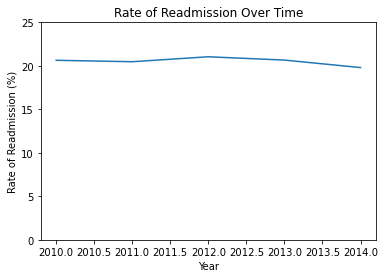

```python
#Visualization
#Line graph for the rate over time
year = BHOmean.index
plt.plot(year,BHOmean['Rate'])
plt.title("Rate of Readmission Over Time")
plt.xlabel("Year")
plt.ylabel("Rate of Readmission (%)")
plt.ylim((0,25.0))
plt.show()
```

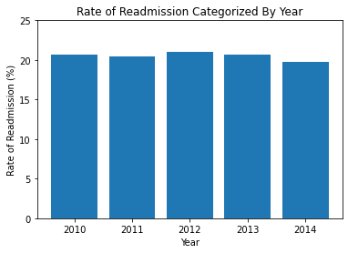

```python
#Bar graph for mean rate per year
plt.bar(year,BHOmean['Rate'])
plt.title("Rate of Readmission Categorized By Year")
plt.xlabel("Year")
plt.ylabel("Rate of Readmission (%)")
plt.ylim((0,25.0))
plt.show()
```

Results and Discussion:

There is no significant difference between the mean rates of the beginning of the dataset and the end. There also was no trend that was detected in the data. The program appears to have had no effect on the rates since there is no difference in the values from one year to another. That means that whichever factors may have influenced the readmission rates, including the BHO initiative, did not appear to have an effect on the readmission rates.

Ethical Consequences:

When dealing with data about mental illness, specifically, data that describes actions taken by someone who is vulnerable, there are many ethical consequences. By reducing the readmission and healing process to numbers, the complexity and nuance involved in recovery are lost. This loss can lead those who have gotten readmitted or seeked out the public programs available to help with their mental illness to see this data as reduction of their journey, which could have them feel disappointed in their progress or cause them to lose faith in themselves or the public systems. By showing that the first phase of the initiative was not very effective, this could also lead to public programs losing funding for future initiatives which may have been more effective. This may even create stigma against public mental illness recovery programs in general, with people assuming that they are not worth the effort to maintain or invest in which could prevent new programs from starting as well.

### Citations:

```
Madi, N., Zhao, H., & Li, J. (2007). Hospital readmissions for patients with mental illness in Canada. Healthcare quarterly, 10 2, 30-2 .

Gammon, (1998), Analysis of the stressful effects of hospitalisation and source isolation on coping and psychological constructs. International Journal of Nursing Practice, 4: 84-96. https://doi.org/10.1046/j.1440-172X.1998.00084.x

Burgess, Philip & Bindman, Jonathan & Leese, Morven & Henderson, Claire & Szmukler, George. (2006). Do community treatment orders for mental illness reduce readmission to hospital? An epidemiological study. Social psychiatry and psychiatric epidemiology. 41. 574-9. 10.1007/s00127-006-0063-1.
```